# Intern validering och kalibrering

Erik Bulow

2019-10-03

# Optimism

Mha `rms::validate` gavs mått på optimism gm Bootstrapnig (n = 40 per default, lite lågt kanske men hniner inte köra fler just nu).

# Validering

Subtraheras optimismen från givet AUC ges AUC_est.corr enl följande:

[output not shown]

Görs samma modifikation på CI-gränserna (DeLong) ges:

[output not shown]

Här borde man kanske egentligen göra annorlunda (ta kvantiler direkt från Bootstrap-samlingen)? Diskuteras på nätet men tycks inte vara implementerat i `rms` utan kanske i så fall kräver egen programmering.

Grafiskt:

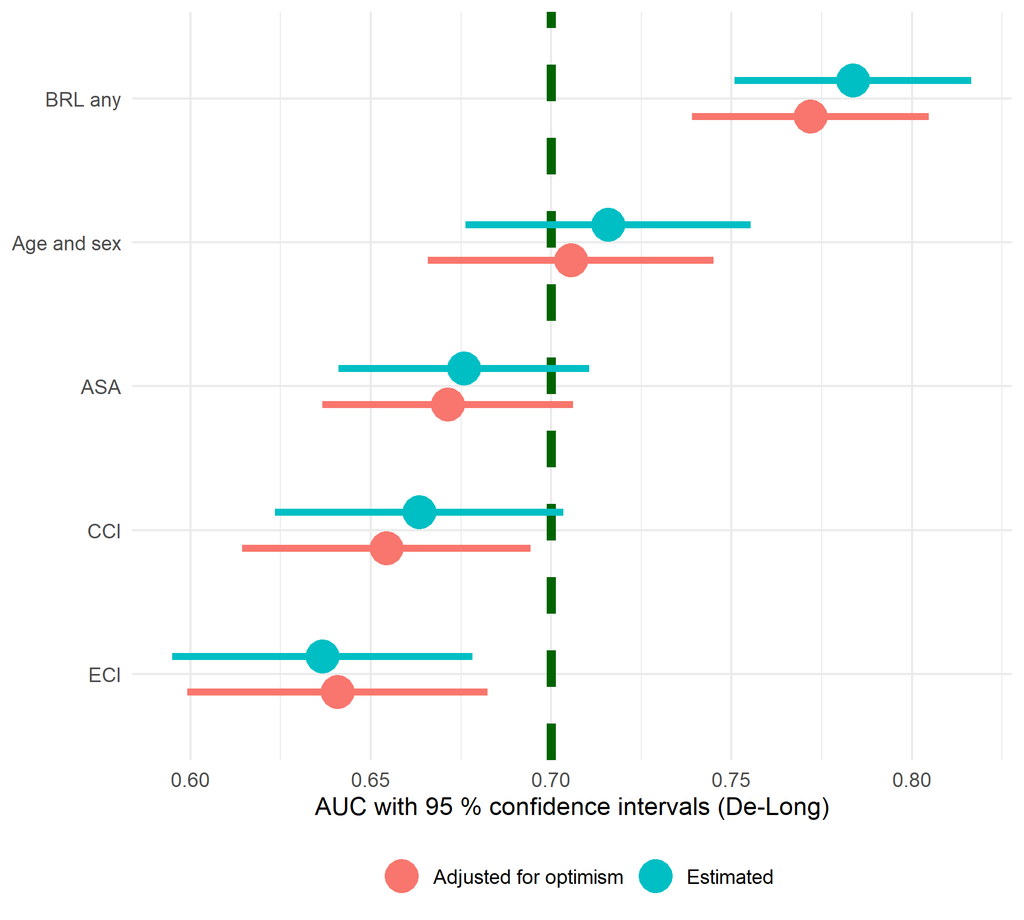

# Kalibrering

`rms::calibrate` ger följande graf. Här framgår att bias-korrektion nite ger så stor effekt i förhållande tlil den totala överskattningen. Obsrevera att x-skalorna skiljer sig mellan olika modeller, dvs kurvorna ligger närmare för t ex “BRL all” men endast i intervallet 0-0.06.

OBS! Osäker om modellerna med splines (RCS) stämmer då `rms` kodar splines på eget sätt egentligen (vilket jag inte gjorde här).

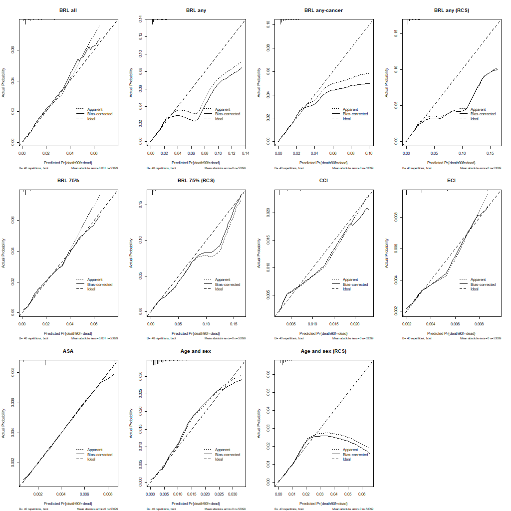

Då jag har lite svårt att avgöra vilkemn avvikelse som kan antas OK kikade jag även på “Calibrarion belts”. Se https://onlinelibrary.wiley.com/doi/full/10.1002/sim.6744

Dessa tar ej hänsyn till optimismen men enl ovan var ju den effekten ganska marginell ändå. Här tror jag att även RCS-modellerna stämmer. Banden blir ju ganska breda ganska snabbt men t ex “BRL any” och “BRL any-cancer” avviker åtm inte med stat sign från den röda linjen (vilket är vad vi önskar).

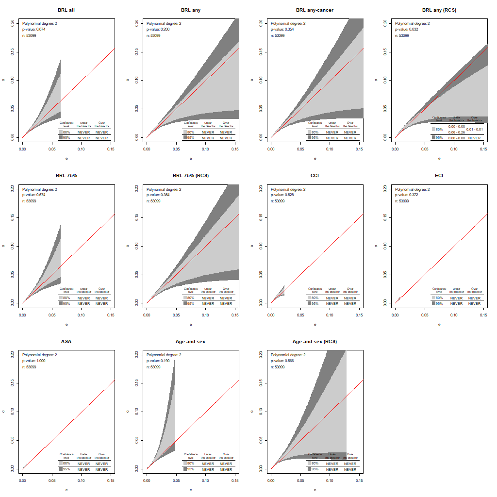